# La correlación entre las inmigraciones y los índices de violencia en México

Inmigraciones vs Violencia

Ponce Sanchez, Max Albert (Líder de grupo)  
Strater Mc Lellan, Luis Eduardo  
Puchuri Orellano, Piero Marcelo  
Cárdenas Aguirre, Sebastian Edgard  
Anticona Puza, Francescolli Gustavo  
Profesor: Rojas Melasquez, Royer Edelwer

# **Introducción**

Este estudio trata un tema sensible el cual es sobre la inmigración y la violencia. En este caso, se esta dando el enfoque en México donde se conoce que tiene una alta taza de violencia, sexismo y discriminación. Por lo que sería de interés saber si hay alguna relación entre estas dos variables.  
Con el paso de los años los países, en su mayoría países latinos, se han visto afectados por una gran cantidad de inmigrantes de diferentes partes del mundo por diversas razones. Este aumento progresivo de inmigraciones ha traído consigo beneficios y daños a la población donde se inmigra. Una de estos posibles daños es el aumento de crímenes/violencia tras la llegada de inmigrantes, sea por la misma población hacia los inmigrantes como los inmigrantes en si. Por ello, es que nos enfocamos en México pues, tienen una cultura muy diversa y un alto flujo de inmigrantes. Por lo que se busca ver una relación entre estos dos factores, el incremento violencia y las inmigraciones.

# **Objetivo**

Evaluar el crecimiento de violencia según las inmigraciones realizadas en México por medio de datos extraídos del Instituto Nacional de Estadística y Geografía(INEGI).

- **Objetivos Específicos**
  - Determinar cómo las inmigraciones en México pueden alterar el orden público.
  - Determinar que indicadores muestran una mayor relevancia para la investigación.
  - Hallar una correlación entre el aumento de violencia y las inmigraciones.

# **Preguntas Plateadas**

| Preguntas | Tipo de pregunta |
| --- | --- |
| *¿Qué relación existe entre el índice de violencia y el de inmigraciones?* | **Plausible** |
| *¿En qué región se presenta mayor índice de violencia en el caso de inmigración?* | **Específica** |
| *¿Se percibe inseguridad/incomodidad en presencia de un inmigrante?* | **Factible** |
| *¿Cuales son los motivos más frecuentes por los que se presenta discriminación?* | **Plausible** |
| *¿Qué tan visibles se presentan las oportunidades a personas inmigrantes al país?* | **Interesante** |
| *¿Cómo se percibe la presencia de un inmigrante?* | **Interesante** |
| *¿Las personas con menor nivel socioeconómico son las que más rechazan a los inmigrantes?* | **Interesante** |

# **Marco Teórico**

- **Población Objetivo**: Es el conjunto de individuos que conforman dos grupos, los inmigrantes y los ciudadanos mexicanos.
- **Unidades Muestrales**: Inmigrantes y los ciudadanos mexicanos.
- **Obtención de Muestra**
  - La inseguridad pública: causas y consecuencias.
  - Víctimas, inculpados y sentenciados registrados.
  - Encuesta Nacional de Migración.

# **Variables**:

| Variables | Tipos de variables |
| --- | --- |
| Para usted, ¿Se justifica o no se justifica expulsar de una comunidad a alguien que no es de la religión que tiene la mayoría? | **Categórica** |
| Para usted, ¿Se justifica o no se justifica devolver a un extranjero a su país por no tener papeles? | **Categórica** |
| Para usted, ¿Se justifica o no se justifica discriminar a inmigrantes por practicar costumbres diferentes? | **Categórica** |
| ¿Estaría dispuesto o no estaría dispuesto a permitir que en su casa vivieran personas de otra religión? | **Categórica** |
| ¿Podría decirme, por favor, una palabra que asocie con la expresión ‘frontera norte de México’? | **Categórica** |

# **Variables**:

| Variables | Tipos de variables |
| --- | --- |
| ¿Podría decirme, por favor, una palabra que asocie con la expresión ‘frontera sur de México’? | **Categórica** |
| Usted cree que los mexicanos que viven en el extranjero deben tener… | **Categórica** |
| Usted considera que desde la crisis económica de 2008 han regresado… | **Categórica** |
| ¿Cuál cree usted que es el principal problema de los mexicanos que regresan al país después de vivir en el extranjero? | **Categórica** |
| Actualmente, ¿cuál considera que es el principal problema para los extranjeros que viven en México? | **Categórica** |

# **Variables**:

| Variables | Tipos de variables |
| --- | --- |
| ¿Tiene usted hijos? ¿Cuántos? | **Numérica** |
| ¿Habla usted algún otro idioma que no sea español? | **Categórica** |
| Sexo | **Categórica** |
| ¿Cuántos años cumplidos tiene usted? | **Numérica** |
| ¿Cuál es el último nivel que estudió o cursó en la escuela? | **Categórica** |
| Condición de Actividad | **Categórica** |

# **Variables**:

| Variables | Tipos de variables |
| --- | --- |
| Estado Civil | **Categórica** |
| Ingreso Individual | **Categórica** |
| Ingreso Familiar | **Categórica** |
| Región | **Categórica** |
| Estrato | **Categórica** |
| Tamaño de localidad | **Numérica** |
| revisión de migraciones | **Numérica** |
| percepción de seguridad pública | **Numérica** |

# **Descriptores Numéricos**

- Año de menor percepción de seguridad pública

```
##    Min. 1st Qu.  Median    Mean 3rd Qu.    Max.
##   19.20   49.20   66.60   61.93   76.00   86.70
```

- Año de mayor percepción de seguridad pública

```
##    Min. 1st Qu.  Median    Mean 3rd Qu.    Max.
##   29.50   58.90   72.10   67.64   78.50   92.60
```

# **Descriptores Gráficos**

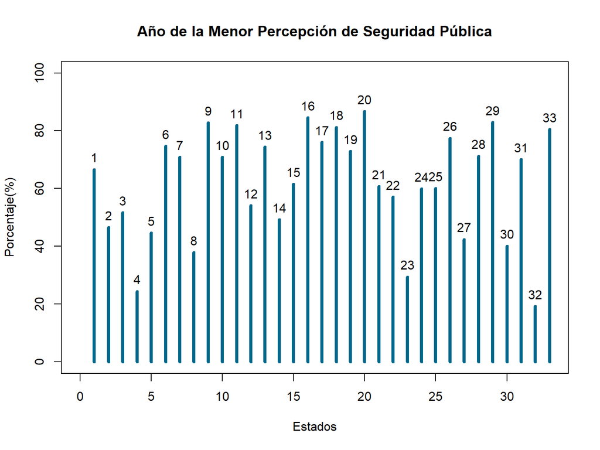

# **Descriptores Gráficos**

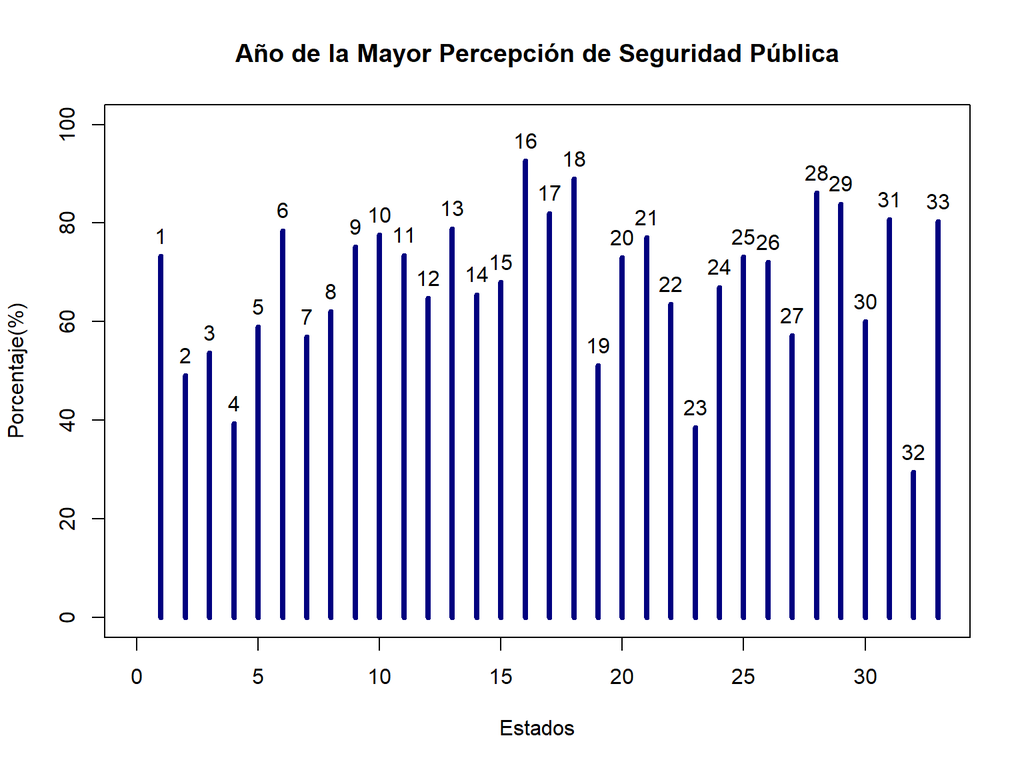

# **Descriptores Gráficos**

| Número | Estado |
| --- | --- |
| 1 | Estados Unidos Mexicanos |
| 2 | Agascalientes |
| 3 | Baja California |
| 4 | Baja California Sur |
| 5 | Campeche |
| 6 | Coahuila de Zaragoza |
| 7 | Colima |
| 8 | Chiapas |
| 9 | Chihuahua |
| 10 | Ciudad de México |
| 11 | Durango |
| 12 | Guanajuato |

# **Descriptores Gráficos**

| Número | Estado |
| --- | --- |
| 13 | Guerrero |
| 14 | Hidalgo |
| 15 | Jalisco |
| 16 | México |
| 17 | Michoacán de Ocampo |
| 18 | Morelos |
| 19 | Nayarit |
| 20 | Nuevo León |
| 21 | Oaxaca |
| 22 | Puebla |
| 23 | Querétaro |
| 24 | Quintana Roo |

# **Descriptores Gráficos**

| Número | Estado |
| --- | --- |
| 25 | San Luis Potosí |
| 26 | Sinaloa |
| 27 | Sonora |
| 28 | Tabasco |
| 29 | Tamaulipas |
| 30 | Tlaxcala |
| 31 | Veracruz de Ignacio de la LLave |
| 32 | Yucatán |
| 33 | Zacatecas |

# **Descriptores Gráficos**

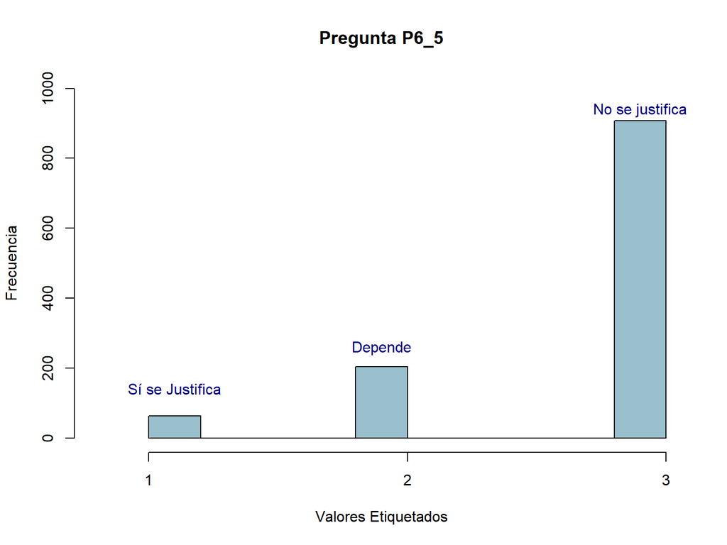

P6_5: ¿Se justifica o no se justifica expulsar de una comunidad a alguien que no es de la religión que tiene la mayoría?

# **Metodología**

Recopilar las bases de datos(formato .csv) de la página del Instituto Nacional de Estadística y Geografía(INEGI), Universidad Nacional Autónoma de México(UNAM) , para obtener indicadores de aumento de violencia en México.

# **Diagrama de Gantt**

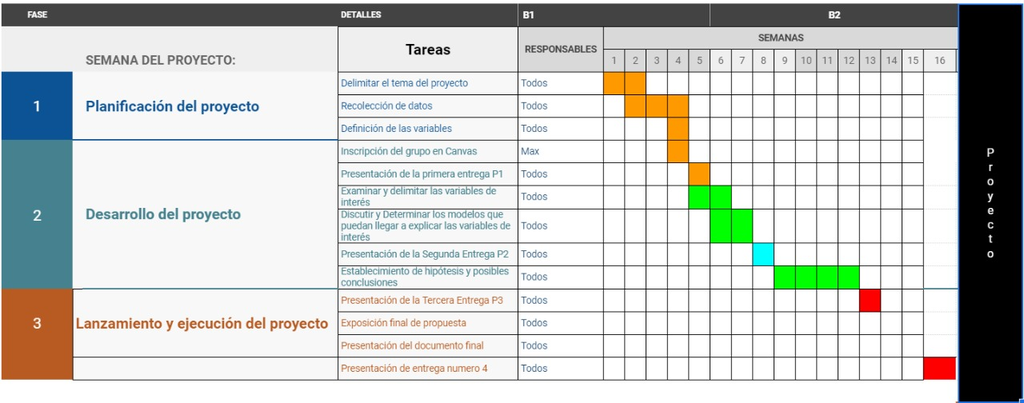

Diagrama de Gantt

# **Referencias**

- Tapia Pérez, José (2013). La inseguridad pública: causas y consecuencias. El Cotidiano, (180),103-112.[fecha de Consulta 20 de Mayo de 2021]. ISSN: 0186-1840. Disponible en: https://www.redalyc.org/articulo.oa?id=32528338007
- Datos Abiertos de México - datos.gob.mx. (2021). Retrieved 10 May 2021, from https://datos.gob.mx/busca/dataset?tags=víctimas
- Biblioteca Los mexicanos vistos por sí mismos. Los grandes temas nacionales / Encuesta Nacional de Migración. (2021). Retrieved 10 May 2021, from http://www.losmexicanos.unam.mx/migracion/encuesta_nacional.html

# **Referencias**

- Morales Mena, A., & Caicedo, M. (2015, 25 agosto). Encuesta Nacional de Migración. Biblioteca Los Mexicanos vistos por sí mismos Los grandes temas nacionales. http://www.losmexicanos.unam.mx/migracion/encuesta_nacional.html https://datos.gob.mx/busca/dataset/migracion-mundial https://www.kaggle.com/zikazika/analysis-of-world-crime?select=Enrolment_in_Grade_1_of_primary_education1.csv
- Muñoz Rincón, D. (2021). ¿Cómo se dice:. Retrieved 17 May 2021, from https://www.upb.edu.co/es/central-blogs/ortografia/como-se-dice-migrante-emigrante-inmigrante
- Violencia. (2021). Retrieved 17 May 2021, from https://www.who.int/topics/violence/es/